# Whirlwind Wizardry: Unraveling the Patterns of Tornado Impact

Morgan Johnston

## Project Goal

The purpose of this project is to analyze governmental records of tornadoes across the United States and identify possible influencing factors that can impact property damage, crop loss, and to see if there are peak regions and time frames that those most destructive tornadoes occur.

### Background Information

[video not shown]

Tornadoes are among the most violent and dramatic weather phenomena on Earth, known for their destructive power and unpredictable nature. Characterized by their rotating column of air that reaches from a thunderstorm to the ground, tornadoes can cause devastating damage in a matter of minutes.

These weather events vary widely in size, shape, and intensity, typically measured by the Enhanced Fujita (EF) scale, which ranges from EF0, indicating minor damage, to EF5, denoting severe destruction with winds exceeding 200 miles per hour. Tornadoes are most common in the United States, particularly in the region colloquially known as “Tornado Alley,” which includes parts of Texas, Oklahoma, Kansas, and Nebraska. However, they can occur almost anywhere in the world under the right conditions.

The formation of tornadoes is linked to specific atmospheric conditions, often involving severe thunderstorms where warm, moist air collides with cold, dry air, helped by high wind shear. Understanding the dynamics of tornadoes is crucial for improving prediction methods and reducing the potential impact on lives and property.

### Project Importance

Analyzing governmental tornado records is essential for improving disaster preparedness and response. By identifying key factors like geographic locations, times of year, and specific tornado characteristics, this analysis helps tailor risk assessment and emergency planning.

These insights enable better resource allocation to high-risk areas during peak tornado seasons and enhance public safety through targeted awareness programs. Additionally, understanding the economic impacts on properties and agriculture informs policy decisions and aids in effective aid distribution.

Ultimately, this project enhances community resilience and reduces the economic and human costs associated with tornadoes.

## Exploratory Data Analysis

### Libraries and Methods

```r
library(tidyverse)
library(easystats)
library(modelr)
library(DT)
library(MASS)
library(leaflet)
library(shiny)
library(bslib)
library(sf)
library(lutz)
library(plotly)
library(caret)
library(broom)
library(kableExtra)
```

### A Glimpse of the Data

There was a lot of data to work with, and none of it was clean to begin with. I combined several data sets to merge in mapping data for regions, time zones, and county information as well as performed general cleaning. Below is a table that shows the description of the cleaned data set that I used in my analyses.

```r
skim_variable <- names(full_df)

full_df %>%
    skimr::skim() %>%
    dplyr::select(skim_type, skim_variable) %>%
    datatable(colnames = c("Types", 'Name'))
```

|  | Types | Name |
| --- | --- | --- |
| 1 | POSIXct | datetime |
| 2 | character | month |
| 3 | character | state_abbr |
| 4 | character | state_fips |
| 5 | character | county_number |
| 6 | character | time_zone |
| 7 | character | county_name |
| 8 | character | long_name |
| 9 | character | region_name |
| 10 | numeric | number_so_far |

[output cut: 15 more lines]

### Crop Loss and Property Loss

I began by looking at some exploratory plots describing property loss and crop loss over time. Due to various factors such as poor historical data, inflation, and various other factors, the data is skewed towards recent years as data collection has improved. Although I can provide no difinitive answers regarding the skew, it does warrant futher exploration in the future.

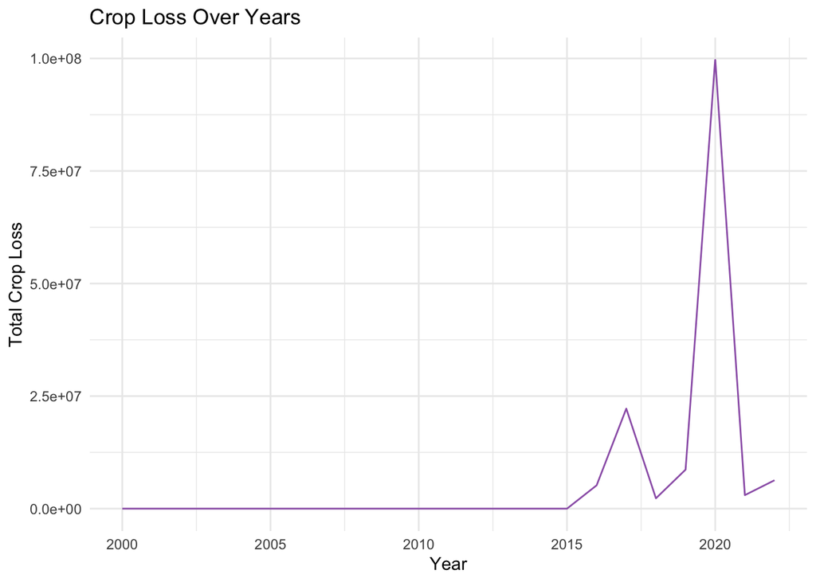

```r
full_df %>%
    filter(crop_loss != 0 & !is.na(crop_loss)) %>%
    mutate(year = year(datetime)) %>%
    group_by(year) %>%
    summarise(total_crop_loss = sum(crop_loss, na.rm = TRUE)) %>%
    ggplot(aes(x = year, y = total_crop_loss)) +
    geom_line(group = 1, color = "#9C63B5") +
    labs(title = "Crop Loss Over Years",
         x = "Year",
         y = "Total Crop Loss") +
    theme_minimal()
```

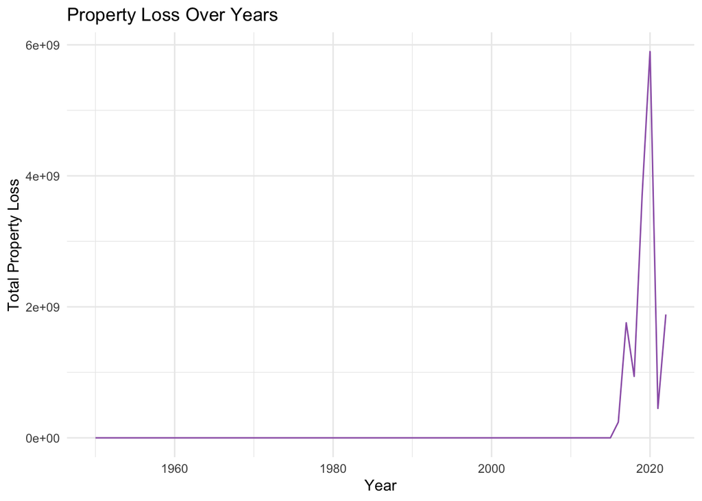

```r
full_df %>%
    filter(property_loss != 0) %>%
    mutate(year = year(datetime)) %>%
    group_by(year) %>%
    summarise(total_prop_loss = sum(property_loss, na.rm = TRUE)) %>%
    ggplot(aes(x = year, y = total_prop_loss)) +
    geom_line(group = 1, color = "#9C63B5") +
    labs(title = "Property Loss Over Years",
         x = "Year",
         y = "Total Property Loss") +
    theme_minimal()
```

### Regional Impact on Tornado Formation

I next looked at tornadoes grouped by region in the United States. Although there were no surprises, it confirmed my suspicions that the highest number of tornadoes occur in the Southern United States, followed closely by the Midwest.

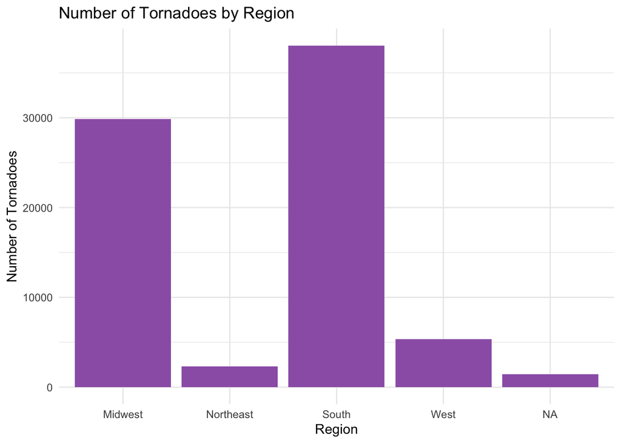

```r
full_df %>%
    ggplot(aes(x = region_name)) +
    geom_bar(fill = "#9C63B5") +
    labs(title = "Number of Tornadoes by Region",
         x = "Region",
         y = "Number of Tornadoes") +
    theme_minimal()
```

This was further substantiated with Texas being the state with the highest recorded occurences of tornadoes.

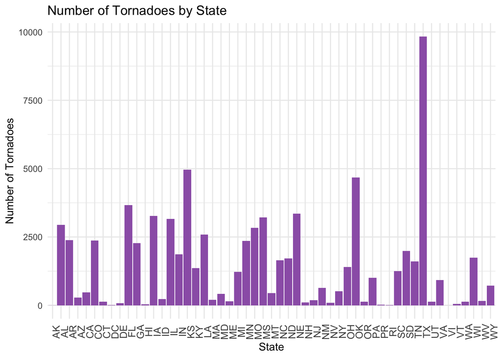

```r
full_df %>%
    ggplot(aes(x = state_abbr)) +
    geom_bar(fill = "#9C63B5") +
    labs(title = "Number of Tornadoes by State",
         x = "State",
         y = "Number of Tornadoes") +
    theme_minimal() +
    theme(axis.text.x = element_text(angle = 90, size = 10))
```

For a more hands on exploration of the tornado data, I have provided an interactive map that displays tornado paths by year over the United States. Their color corresponds with their f-scale severity.

```r
knitr::include_app('https://morganbjohnston.shinyapps.io/Tornados/')
```

[interactive chart not shown]

## Modeling

### Property Loss Linear Regression Modeling

To look at factors that may impact property damage, I decided to build several linear regression models. I compared the results and determined the best model below.

```r
trainIndex <- caret::createDataPartition(
    full_df$property_loss,
    p=0.8,
    list=FALSE)

train <- full_df[trainIndex, ]
test <- full_df[-trainIndex, ]

model_1 <- train %>%
    glm(formula=property_loss ~ f_scale +
            injuries +
            width_yards +
            length_miles +
            fatalities,
        data=.,
        family=gaussian())

model_2 <- train %>%
    glm(formula=property_loss ~ f_scale *
            injuries *
            width_yards *
            length_miles *
            fatalities,
        data=.,
        family=gaussian())

model_3 <- train %>%
    glm(formula=property_loss ~ f_scale +
            injuries +
            width_yards *
            length_miles +
            fatalities,
        data=.,
        family=gaussian())

# compare_models(model_1, model_2, model_3)
# compare_performance(model_1, model_2, model_3)

step <- stepAIC(model_2)
```

```
## Start:  AIC=2114039
## property_loss ~ f_scale * injuries * width_yards * length_miles *
##     fatalities
##
##                                                        Df   Deviance     AIC
## <none>                                                    2.8836e+18 2114039
## - f_scale:injuries:width_yards:length_miles:fatalities  1 2.8959e+18 2114298
```

```r
# step$model
# step$formula

winning_model <- glm(data = full_df, formula = formula(step))
```

#### Model 1 Results

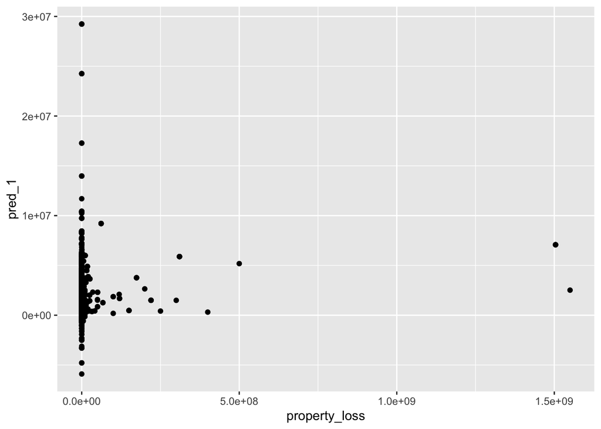

```r
full_df$pred_1 <- predict(model_1, full_df)
full_df %>%
    ggplot(aes(x=property_loss, y=pred_1)) +
    geom_point()
```

#### Model 2 Results

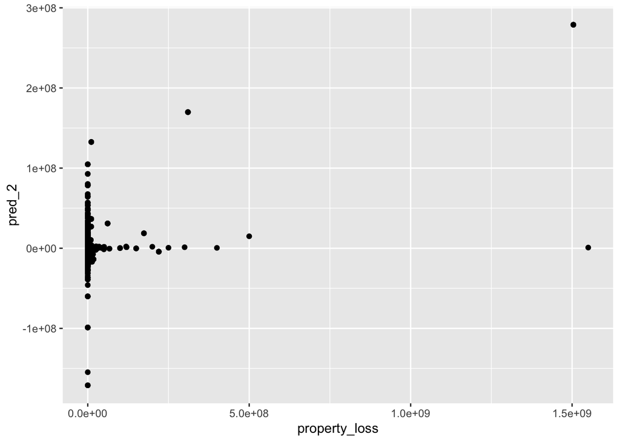

```r
full_df$pred_2 <- predict(model_2, full_df)
full_df %>%
    ggplot(aes(x=property_loss, y=pred_2)) +
    geom_point()
```

#### Model 3 Results

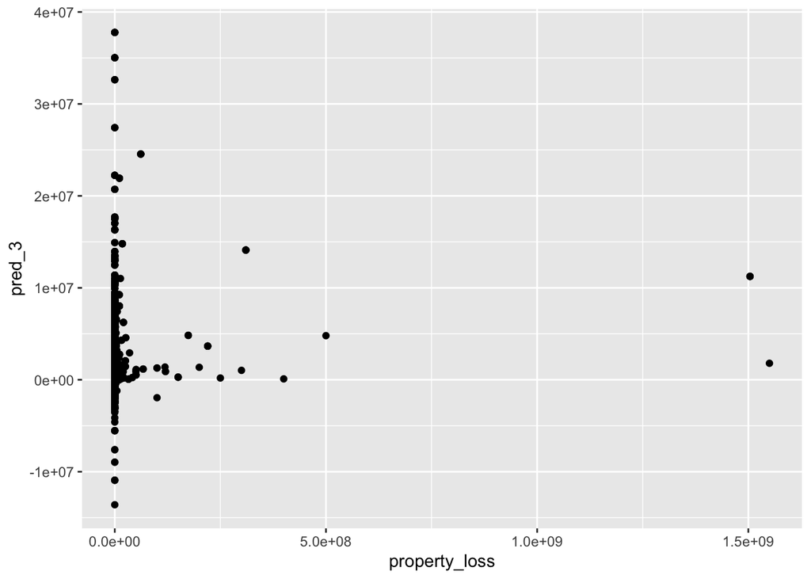

```r
full_df$pred_3 <- predict(model_3, full_df)
full_df %>%
    ggplot(aes(x=property_loss, y=pred_3)) +
    geom_point()
```

#### Best Model Results

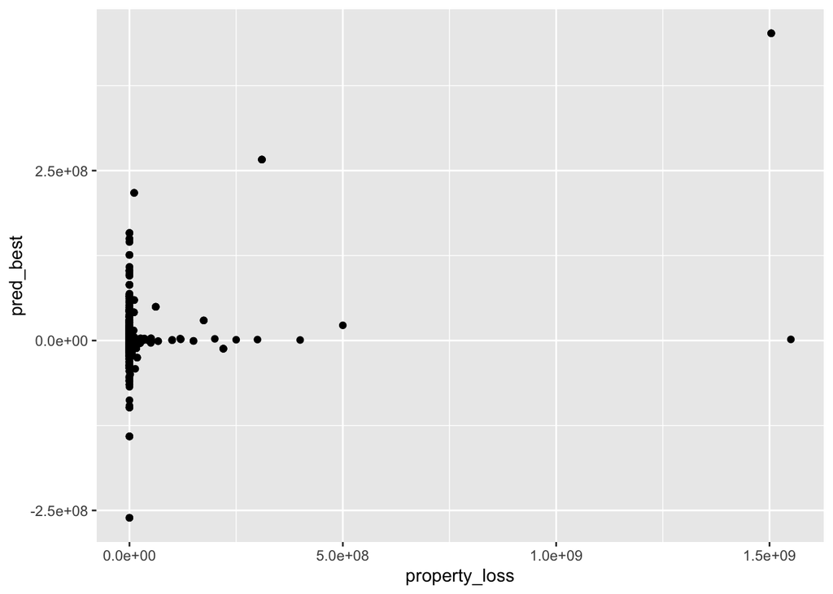

```r
full_df$pred_best <- predict(winning_model, full_df)
full_df %>%
    ggplot(aes(x=property_loss, y=pred_best)) +
    geom_point()
```

#### Model Comparison, Cross-Validation, and Metrics

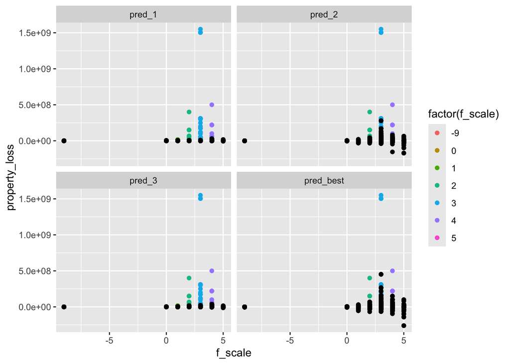

```r
full_df %>%
    pivot_longer(starts_with("pred")) %>%
    ggplot(aes(x = f_scale, y=property_loss, color=factor(f_scale))) +
    geom_point() +
    geom_point(aes(y=value), color = "black") +
    facet_wrap(~name)
```

```r
predictions <- test %>%
    modelr::add_predictions(winning_model) %>%
    mutate(error = abs(pred - property_loss))

summary(predictions$error)
```

```
##      Min.   1st Qu.    Median      Mean   3rd Qu.      Max.
## 3.100e+01 8.950e+04 1.673e+05 9.854e+05 3.371e+05 1.548e+09
```

```r
full_pred <- full_df %>%
    modelr::add_predictions(winning_model) %>%
    mutate(error = abs(pred - property_loss))

summary(full_pred$error)
```

```
##      Min.   1st Qu.    Median      Mean   3rd Qu.      Max.
## 9.000e+00 8.829e+04 1.673e+05 8.073e+05 3.291e+05 1.548e+09
```

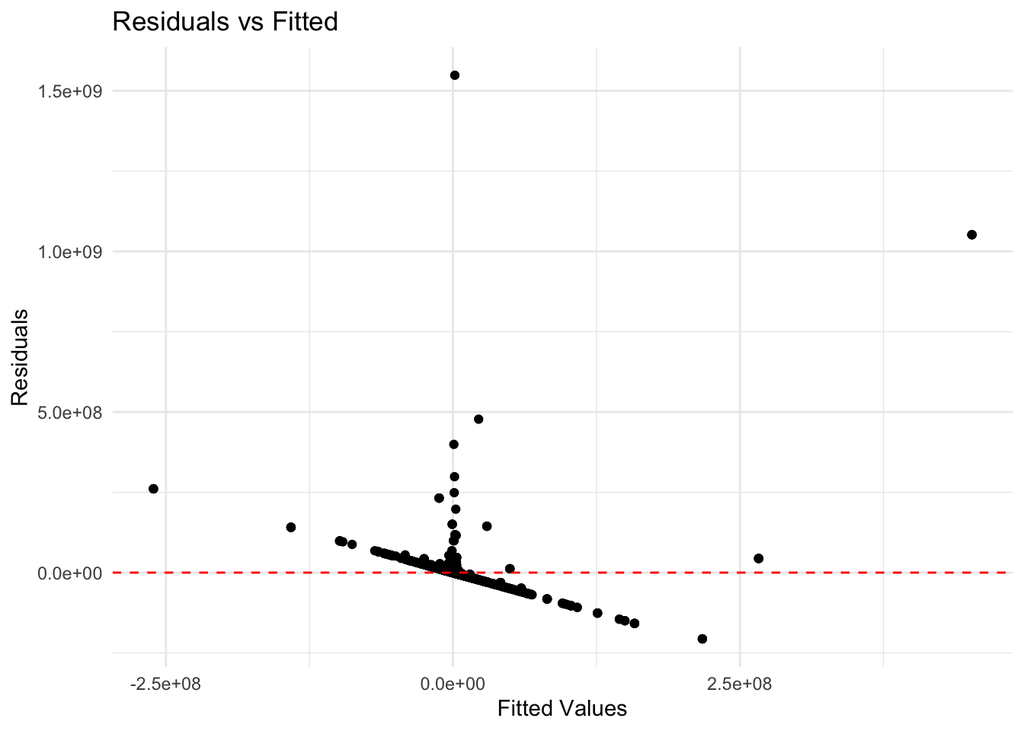

```r
residuals <- residuals(winning_model)
fitted <- fitted.values(winning_model)

ggplot(data = NULL, aes(x = fitted, y = residuals)) +
    geom_point() +
    geom_hline(yintercept = 0, linetype = "dashed", color = "red") +
    labs(x = "Fitted Values", y = "Residuals", title = "Residuals vs Fitted") +
    theme_minimal()
```

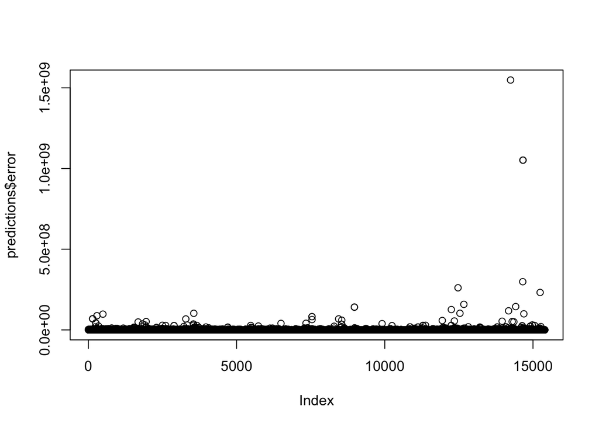

```r
plot(predictions$error)
```

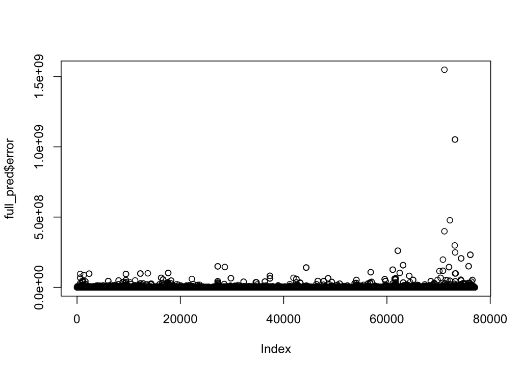

```r
plot(full_pred$error)
```

### Crop Loss Linear Regression Modeling

I took the lessons I learned from property loss modeling and applied it to crop loss.

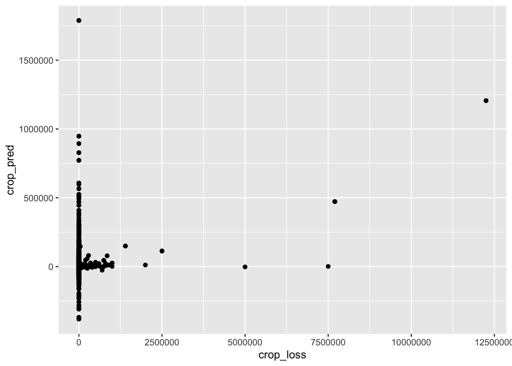

```r
trainIndex <- caret::createDataPartition(full_df$crop_loss, p=0.8, list=FALSE)

train <- full_df[trainIndex, ]
test <- full_df[-trainIndex, ]

model <- train %>%
    glm(formula=crop_loss ~ f_scale *
            injuries *
            width_yards *
            length_miles *
            fatalities,
        data=.,
        family=gaussian())

full_df$crop_pred <- predict(model, full_df)
full_df %>%
    ggplot(aes(x=crop_loss, y=crop_pred)) +
    geom_point()
```

```r
predictions <- test %>%
    modelr::add_predictions(model) %>%
    mutate(error = abs(pred - crop_loss))

summary(predictions$error)
```

```
##     Min.  1st Qu.   Median     Mean  3rd Qu.     Max.
##        0      170     1238     7519     2024 11044094
```

```r
full_pred <- full_df %>%
    modelr::add_predictions(model) %>%
    mutate(error = abs(pred - crop_loss))

summary(full_pred$error)
```

```
##     Min.  1st Qu.   Median     Mean  3rd Qu.     Max.
##        0      174     1266     6421     2024 11044094
```

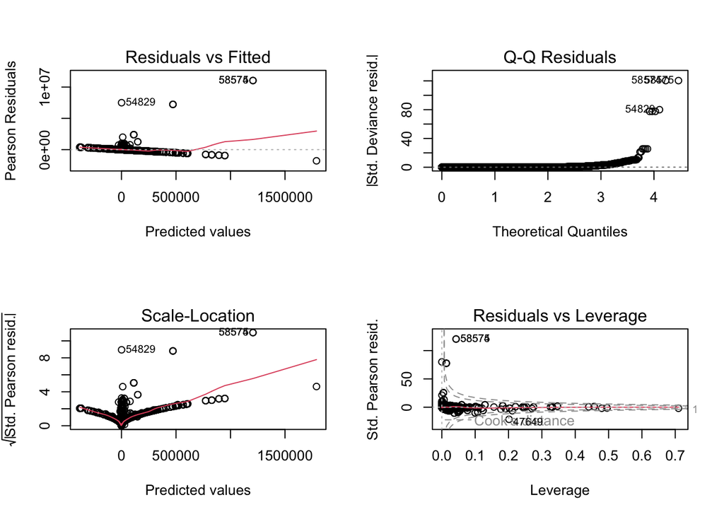

```r
par(mfrow=c(2,2))
plot(model)
```

This model also lacked much accuracy and further analysis will be needed to determine variables that impact crop loss.

## Future Analysis

In the future, I would like to expand and refine the models I used, as well as attempt to look at time series modeling the severity of tornadoes in the United States to see if there is an impact due to global warming. Unfortunately I ran out of time for this, for the moment, but hope to return to this project to dig deeper into this incredibly interesting data set.